# R ve Python ile Temel Makine Öğrenme Algoritmaları

Dr. Uzay Çetin

Bu çalışmada **Sunil Ray** tarafından yazılmış olan [Essentials of Machine Learning Algorithms (with Python and R Codes)](https://www.analyticsvidhya.com/blog/2015/08/common-machine-learning-algorithms/) web sayfasından yararlanılmıştır.

**Sunil Ray** Makine öğrenimi için yararlı bir rehber hazırlamış. Elimizden geldiğince onun rehberliğini takip edeceğiz. `R` ve `Python` kullanarak elimizi kirleteceğiz ve belli başlı temel Makine öğrenme algoritmalarını programlayacağız. Fakat bu algoritmaların altında yatan matematik ve istatistiği şimdilik atlayacağız.

Klasik makine öğrenme algoritmaları 3 ayrılmaktadır.

1. **Danışmanlı (Supervised)**: Burada girdi ve çıktı değerleri verilerek en iyileyen parametreler bulunmaya çalışılır.
   - Örnek: Regresyon, Karar, Rastgele Orman Ağaçları, KNN, Logistic Regresyon
2. **Danışmansız (Unsupervised)**: Burada elimizde çıktı değerleri yoktur. Yalnızca girdi verisine bakarak kesitirim yapılır.
   - Örnek: Apriori algorithm, K-means
3. **Pekiştirmeli (Reinforcement)**: Algoritma deneme-yanılma yoluyla uygun davranışı öğrenir.
   - Örnek: Markov Decision Process

Şimdi bu algoritmalardan bazılarını görelim

### 1. Doğrusal Regresyon

Peşinde olduğumuz matematiksel denklem şudur:
$$y = a x + b$$
Burada

1. $y$ : Bağımlı değişken
2. $x$ : Bağımsız değişken
3. $a$ : Eğim
4. $b$ : Kesen

```r
# Eğitim verisi
x_egitim <- c(3.87, 3.61, 4.33, 3.43, 3.81, 3.83, 3.46, 3.76,3.50)
y_egitim <- c(4.87, 3.93, 6.46, 3.33, 4.38, 4.70, 3.50, 4.50,3.58)
# Test Verisi
x_test  <- c(3.58, 4.19, 3.78, 3.71, 3.73, 3.78)
y_test <- c(3.64, 5.90, 4.43, 4.38, 4.42, 4.25)
x <- data.frame(x_egitim,y_egitim)
# Doğrusal regresyon parametreleri
regresyon <- lm(y_egitim ~ ., data = x)
summary(regresyon)
```

```
Call:
lm(formula = y_egitim ~ ., data = x)

Residuals:
      Min        1Q    Median        3Q       Max
-0.243192  0.005818  0.016527  0.047730  0.073265

Coefficients:
            Estimate Std. Error t value Pr(>|t|)
(Intercept)  -8.4011     0.4810  -17.46 4.97e-07 ***
x_egitim      3.4184     0.1285   26.60 2.72e-08 ***
---
Signif. codes:  0 ‘***’ 0.001 ‘**’ 0.01 ‘*’ 0.05 ‘.’ 0.1 ‘ ’ 1

Residual standard error: 0.1018 on 7 degrees of freedom
Multiple R-squared:  0.9902,    Adjusted R-squared:  0.9888
F-statistic: 707.4 on 1 and 7 DF,  p-value: 2.72e-08
```

```r
show(regresyon$coefficients)
```

```
(Intercept)    x_egitim
  -8.401093    3.418448
```

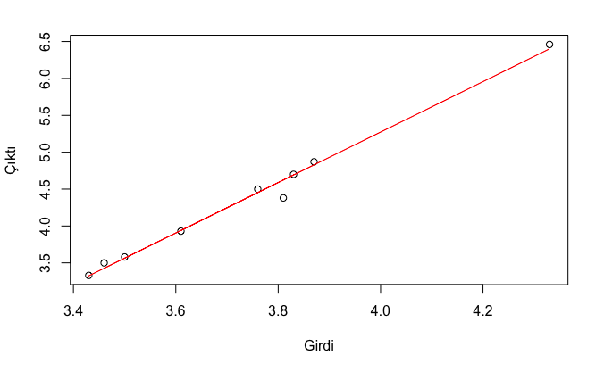

```r
b = regresyon$coefficients['(Intercept)']
a = regresyon$coefficients['x_egitim']
plot(x_egitim, y_egitim, xlab = "Girdi", ylab = "Çıktı")
lines(x_egitim, (x_egitim * a + b) , 'l', col = "red")
```

R’daki hazır veri kümelerinden biri olan **women** verisini kullanarak, doğrusal regresyon analizine devam edelim.

```r
dogrusal <-lm(weight ~ height, data=women)
summary(dogrusal)
```

```
Call:
lm(formula = weight ~ height, data = women)

Residuals:
    Min      1Q  Median      3Q     Max
-1.7333 -1.1333 -0.3833  0.7417  3.1167

Coefficients:
             Estimate Std. Error t value Pr(>|t|)
(Intercept) -87.51667    5.93694  -14.74 1.71e-09 ***
height        3.45000    0.09114   37.85 1.09e-14 ***
---
Signif. codes:  0 ‘***’ 0.001 ‘**’ 0.01 ‘*’ 0.05 ‘.’ 0.1 ‘ ’ 1

Residual standard error: 1.525 on 13 degrees of freedom
Multiple R-squared:  0.991, Adjusted R-squared:  0.9903
F-statistic:  1433 on 1 and 13 DF,  p-value: 1.091e-14
```

Burada `lm(weight ~ height, data=women)` komutunu kullanıyoruz. `~` işareti bağımlı ve bağımsız değişkenleri birbirinden ayırmak için kullanılır.

Değişkenlerimiz şu şekilde,

- $b = -87.51667$
- $a = 3.45000$

Peşinde olduğumuz matematiksel denklem aynı:
$$y = a x + b$$

Değerleri yerine yazarsak

$$weight = 3.45 \; height -87.51667$$

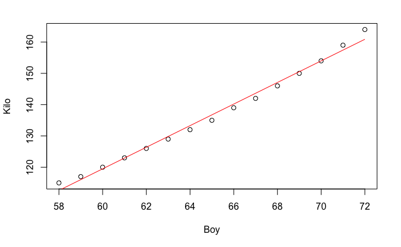

```r
a = 3.45
b = -87.51667
x = women$height
y = women$weight
plot(x, y, xlab = "Boy", ylab = "Kilo")
lines(x, (x * a + b) , 'l', col = "red")
```